# Risk Factor Analysis

## Outcome Variable

**Outcome Variable:** stunted

## Predictor Variables

**Intervention Variable:** birthwt

**Adjustment Set:**

- arm
- sex
- W_mage
- meducyrs
- feducyrs
- vagbrth
- single
- brthmon
- W_parity
- delta_W_mage
- delta_meducyrs
- delta_feducyrs
- delta_vagbrth
- delta_single
- delta_brthmon
- delta_W_parity

## Stratifying Variables

The analysis was stratified on these variable(s):

- agecat
- studyid
- country

## Data Summary

| agecat | studyid | country | birthwt | stunted | n_cell | n |
| --- | --- | --- | --- | --- | --- | --- |
| Birth | ki0047075b-MAL-ED | BANGLADESH | Normal or high birthweight | 0 | 186 | 257 |
| Birth | ki0047075b-MAL-ED | BANGLADESH | Normal or high birthweight | 1 | 16 | 257 |
| Birth | ki0047075b-MAL-ED | BANGLADESH | Low birth weight | 0 | 24 | 257 |
| Birth | ki0047075b-MAL-ED | BANGLADESH | Low birth weight | 1 | 31 | 257 |
| Birth | ki0047075b-MAL-ED | BRAZIL | Normal or high birthweight | 0 | 168 | 191 |
| Birth | ki0047075b-MAL-ED | BRAZIL | Normal or high birthweight | 1 | 15 | 191 |
| Birth | ki0047075b-MAL-ED | BRAZIL | Low birth weight | 0 | 2 | 191 |
| Birth | ki0047075b-MAL-ED | BRAZIL | Low birth weight | 1 | 6 | 191 |
| Birth | ki0047075b-MAL-ED | INDIA | Normal or high birthweight | 0 | 154 | 206 |
| Birth | ki0047075b-MAL-ED | INDIA | Normal or high birthweight | 1 | 18 | 206 |
| Birth | ki0047075b-MAL-ED | INDIA | Low birth weight | 0 | 19 | 206 |
| Birth | ki0047075b-MAL-ED | INDIA | Low birth weight | 1 | 15 | 206 |
| Birth | ki0047075b-MAL-ED | NEPAL | Normal or high birthweight | 0 | 148 | 173 |
| Birth | ki0047075b-MAL-ED | NEPAL | Normal or high birthweight | 1 | 7 | 173 |
| Birth | ki0047075b-MAL-ED | NEPAL | Low birth weight | 0 | 7 | 173 |
| Birth | ki0047075b-MAL-ED | NEPAL | Low birth weight | 1 | 11 | 173 |
| Birth | ki0047075b-MAL-ED | PERU | Normal or high birthweight | 0 | 251 | 287 |
| Birth | ki0047075b-MAL-ED | PERU | Normal or high birthweight | 1 | 18 | 287 |
| Birth | ki0047075b-MAL-ED | PERU | Low birth weight | 0 | 2 | 287 |
| Birth | ki0047075b-MAL-ED | PERU | Low birth weight | 1 | 16 | 287 |
| Birth | ki0047075b-MAL-ED | SOUTH AFRICA | Normal or high birthweight | 0 | 227 | 262 |
| Birth | ki0047075b-MAL-ED | SOUTH AFRICA | Normal or high birthweight | 1 | 17 | 262 |
| Birth | ki0047075b-MAL-ED | SOUTH AFRICA | Low birth weight | 0 | 7 | 262 |
| Birth | ki0047075b-MAL-ED | SOUTH AFRICA | Low birth weight | 1 | 11 | 262 |
| Birth | ki0047075b-MAL-ED | TANZANIA, UNITED REPUBLIC OF | Normal or high birthweight | 0 | 104 | 123 |
| Birth | ki0047075b-MAL-ED | TANZANIA, UNITED REPUBLIC OF | Normal or high birthweight | 1 | 12 | 123 |
| Birth | ki0047075b-MAL-ED | TANZANIA, UNITED REPUBLIC OF | Low birth weight | 0 | 1 | 123 |
| Birth | ki0047075b-MAL-ED | TANZANIA, UNITED REPUBLIC OF | Low birth weight | 1 | 6 | 123 |
| Birth | ki1000108-CMC-V-BCS-2002 | INDIA | Normal or high birthweight | 0 | 70 | 90 |
| Birth | ki1000108-CMC-V-BCS-2002 | INDIA | Normal or high birthweight | 1 | 10 | 90 |

[output cut: 286 more lines]

The following strata were considered:

- agecat: 24 months, studyid: ki0047075b-MAL-ED, country: BANGLADESH
- agecat: 24 months, studyid: ki0047075b-MAL-ED, country: BRAZIL
- agecat: 24 months, studyid: ki0047075b-MAL-ED, country: INDIA
- agecat: 24 months, studyid: ki0047075b-MAL-ED, country: NEPAL
- agecat: 24 months, studyid: ki0047075b-MAL-ED, country: PERU
- agecat: 24 months, studyid: ki0047075b-MAL-ED, country: SOUTH AFRICA
- agecat: 24 months, studyid: ki0047075b-MAL-ED, country: TANZANIA, UNITED REPUBLIC OF
- agecat: 24 months, studyid: ki1000108-CMC-V-BCS-2002, country: INDIA
- agecat: 24 months, studyid: ki1000108-IRC, country: INDIA
- agecat: 24 months, studyid: ki1017093-NIH-Birth, country: BANGLADESH
- agecat: 24 months, studyid: ki1017093b-PROVIDE, country: BANGLADESH
- agecat: 24 months, studyid: ki1017093c-NIH-Crypto, country: BANGLADESH
- agecat: 24 months, studyid: ki1066203-TanzaniaChild2, country: TANZANIA, UNITED REPUBLIC OF
- agecat: 24 months, studyid: ki1101329-Keneba, country: GAMBIA
- agecat: 24 months, studyid: ki1114097-CMIN, country: BANGLADESH
- agecat: 24 months, studyid: ki1114097-CMIN, country: PERU
- agecat: 24 months, studyid: ki1114097-CONTENT, country: PERU
- agecat: 24 months, studyid: ki1119695-PROBIT, country: BELARUS
- agecat: 24 months, studyid: ki1126311-ZVITAMBO, country: ZIMBABWE
- agecat: 24 months, studyid: ki1135781-COHORTS, country: GUATEMALA
- agecat: 24 months, studyid: ki1135781-COHORTS, country: INDIA
- agecat: 24 months, studyid: ki1135781-COHORTS, country: PHILIPPINES
- agecat: 24 months, studyid: kiGH5241-JiVitA-3, country: BANGLADESH
- agecat: 24 months, studyid: kiGH5241-JiVitA-4, country: BANGLADESH
- agecat: 6 months, studyid: ki0047075b-MAL-ED, country: BANGLADESH
- agecat: 6 months, studyid: ki0047075b-MAL-ED, country: BRAZIL
- agecat: 6 months, studyid: ki0047075b-MAL-ED, country: INDIA
- agecat: 6 months, studyid: ki0047075b-MAL-ED, country: NEPAL
- agecat: 6 months, studyid: ki0047075b-MAL-ED, country: PERU
- agecat: 6 months, studyid: ki0047075b-MAL-ED, country: SOUTH AFRICA
- agecat: 6 months, studyid: ki0047075b-MAL-ED, country: TANZANIA, UNITED REPUBLIC OF
- agecat: 6 months, studyid: ki1000108-CMC-V-BCS-2002, country: INDIA
- agecat: 6 months, studyid: ki1000108-IRC, country: INDIA
- agecat: 6 months, studyid: ki1000109-EE, country: PAKISTAN
- agecat: 6 months, studyid: ki1000109-ResPak, country: PAKISTAN
- agecat: 6 months, studyid: ki1000304b-SAS-CompFeed, country: INDIA
- agecat: 6 months, studyid: ki1017093-NIH-Birth, country: BANGLADESH
- agecat: 6 months, studyid: ki1017093b-PROVIDE, country: BANGLADESH
- agecat: 6 months, studyid: ki1017093c-NIH-Crypto, country: BANGLADESH
- agecat: 6 months, studyid: ki1066203-TanzaniaChild2, country: TANZANIA, UNITED REPUBLIC OF
- agecat: 6 months, studyid: ki1101329-Keneba, country: GAMBIA
- agecat: 6 months, studyid: ki1114097-CMIN, country: BANGLADESH
- agecat: 6 months, studyid: ki1114097-CMIN, country: BRAZIL
- agecat: 6 months, studyid: ki1114097-CMIN, country: GUINEA-BISSAU
- agecat: 6 months, studyid: ki1114097-CMIN, country: PERU
- agecat: 6 months, studyid: ki1114097-CONTENT, country: PERU
- agecat: 6 months, studyid: ki1119695-PROBIT, country: BELARUS
- agecat: 6 months, studyid: ki1126311-ZVITAMBO, country: ZIMBABWE
- agecat: 6 months, studyid: ki1135781-COHORTS, country: GUATEMALA
- agecat: 6 months, studyid: ki1135781-COHORTS, country: INDIA
- agecat: 6 months, studyid: ki1135781-COHORTS, country: PHILIPPINES
- agecat: 6 months, studyid: kiGH5241-JiVitA-3, country: BANGLADESH
- agecat: 6 months, studyid: kiGH5241-JiVitA-4, country: BANGLADESH
- agecat: Birth, studyid: ki0047075b-MAL-ED, country: BANGLADESH
- agecat: Birth, studyid: ki0047075b-MAL-ED, country: BRAZIL
- agecat: Birth, studyid: ki0047075b-MAL-ED, country: INDIA
- agecat: Birth, studyid: ki0047075b-MAL-ED, country: NEPAL
- agecat: Birth, studyid: ki0047075b-MAL-ED, country: PERU
- agecat: Birth, studyid: ki0047075b-MAL-ED, country: SOUTH AFRICA
- agecat: Birth, studyid: ki0047075b-MAL-ED, country: TANZANIA, UNITED REPUBLIC OF
- agecat: Birth, studyid: ki1000108-CMC-V-BCS-2002, country: INDIA
- agecat: Birth, studyid: ki1000108-IRC, country: INDIA
- agecat: Birth, studyid: ki1000109-EE, country: PAKISTAN
- agecat: Birth, studyid: ki1000109-ResPak, country: PAKISTAN
- agecat: Birth, studyid: ki1000304b-SAS-CompFeed, country: INDIA
- agecat: Birth, studyid: ki1017093-NIH-Birth, country: BANGLADESH
- agecat: Birth, studyid: ki1017093c-NIH-Crypto, country: BANGLADESH
- agecat: Birth, studyid: ki1101329-Keneba, country: GAMBIA
- agecat: Birth, studyid: ki1114097-CMIN, country: BANGLADESH
- agecat: Birth, studyid: ki1114097-CMIN, country: BRAZIL
- agecat: Birth, studyid: ki1114097-CMIN, country: PERU
- agecat: Birth, studyid: ki1114097-CONTENT, country: PERU
- agecat: Birth, studyid: ki1119695-PROBIT, country: BELARUS
- agecat: Birth, studyid: ki1126311-ZVITAMBO, country: ZIMBABWE
- agecat: Birth, studyid: ki1135781-COHORTS, country: GUATEMALA
- agecat: Birth, studyid: ki1135781-COHORTS, country: INDIA
- agecat: Birth, studyid: ki1135781-COHORTS, country: PHILIPPINES
- agecat: Birth, studyid: kiGH5241-JiVitA-3, country: BANGLADESH
- agecat: Birth, studyid: kiGH5241-JiVitA-4, country: BANGLADESH

### Dropped Strata

Some strata were dropped due to rare outcomes:

- agecat: Birth, studyid: ki0047075b-MAL-ED, country: BRAZIL
- agecat: Birth, studyid: ki0047075b-MAL-ED, country: PERU
- agecat: Birth, studyid: ki0047075b-MAL-ED, country: TANZANIA, UNITED REPUBLIC OF
- agecat: Birth, studyid: ki1000108-CMC-V-BCS-2002, country: INDIA
- agecat: Birth, studyid: ki1000109-EE, country: PAKISTAN
- agecat: Birth, studyid: ki1000109-ResPak, country: PAKISTAN
- agecat: Birth, studyid: ki1017093-NIH-Birth, country: BANGLADESH
- agecat: Birth, studyid: ki1017093c-NIH-Crypto, country: BANGLADESH
- agecat: Birth, studyid: ki1114097-CMIN, country: BANGLADESH
- agecat: Birth, studyid: ki1114097-CMIN, country: BRAZIL
- agecat: Birth, studyid: ki1114097-CMIN, country: PERU
- agecat: Birth, studyid: ki1114097-CONTENT, country: PERU
- agecat: Birth, studyid: ki1119695-PROBIT, country: BELARUS
- agecat: 6 months, studyid: ki0047075b-MAL-ED, country: BRAZIL
- agecat: 6 months, studyid: ki0047075b-MAL-ED, country: TANZANIA, UNITED REPUBLIC OF
- agecat: 6 months, studyid: ki1000109-ResPak, country: PAKISTAN
- agecat: 6 months, studyid: ki1114097-CMIN, country: BANGLADESH
- agecat: 6 months, studyid: ki1114097-CMIN, country: BRAZIL
- agecat: 6 months, studyid: ki1114097-CMIN, country: GUINEA-BISSAU
- agecat: 6 months, studyid: ki1114097-CMIN, country: PERU
- agecat: 6 months, studyid: ki1114097-CONTENT, country: PERU
- agecat: 6 months, studyid: ki1119695-PROBIT, country: BELARUS
- agecat: 24 months, studyid: ki0047075b-MAL-ED, country: BRAZIL
- agecat: 24 months, studyid: ki0047075b-MAL-ED, country: PERU
- agecat: 24 months, studyid: ki0047075b-MAL-ED, country: SOUTH AFRICA
- agecat: 24 months, studyid: ki0047075b-MAL-ED, country: TANZANIA, UNITED REPUBLIC OF
- agecat: 24 months, studyid: ki1066203-TanzaniaChild2, country: TANZANIA, UNITED REPUBLIC OF
- agecat: 24 months, studyid: ki1114097-CMIN, country: BANGLADESH
- agecat: 24 months, studyid: ki1114097-CMIN, country: PERU
- agecat: 24 months, studyid: ki1114097-CONTENT, country: PERU
- agecat: 24 months, studyid: ki1119695-PROBIT, country: BELARUS
- agecat: 24 months, studyid: ki1135781-COHORTS, country: GUATEMALA

## Methods Detail

We’re interested in the causal parameters $E[Y_a]$ for all values of $a \in \mathcal{A}$. These parameters represent the mean outcome if, possibly contrary to fact, we intervened to set all units to have $A=a$. Under the randomization and positivity assumptions, these are identified by the statistical parameters $\psi_a=E_W[E_{Y|A,W}(Y|A=a,W)]$. In addition, we’re interested in the mean of $Y$, $E[Y]$ under no intervention (the observed mean). We will estimate these parameters by using SuperLearner to fit the relevant likelihood factors – $E_{Y|A,W}(Y|A=a,W)$ and $p(A=a|W)$, and then updating our likelihood fit using a joint TMLE.

For unadjusted analyses ($W=\{\}$), initial likelihoods were estimated using Lrnr_glm to estimate the simple $E(Y|A)$ and Lrnr_mean to estimate $p(A)$. For adjusted analyses, a small library containing Lrnr_glmnet, Lrnr_xgboost, and Lrnr_mean was used.

Having estimated these parameters, we will then use the delta method to estimate relative risks and attributable risks relative to a prespecified baseline level of $A$.

# Results Detail

## Results Plots

[figure not shown]

[figure not shown]

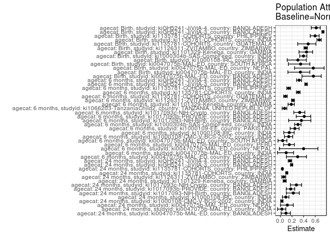

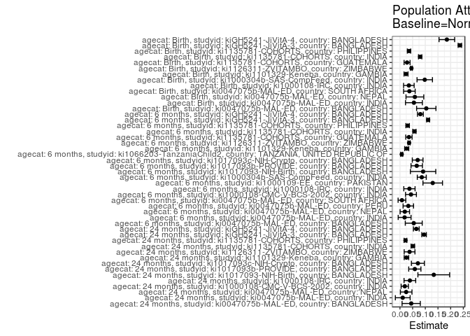

## Results Table

### Parameter: TSM

| agecat | studyid | country | intervention_level | baseline_level | estimate | ci_lower | ci_upper |
| --- | --- | --- | --- | --- | --- | --- | --- |
| Birth | ki0047075b-MAL-ED | BANGLADESH | Normal or high birthweight | NA | 0.0790404 | 0.0417292 | 0.1163516 |
| Birth | ki0047075b-MAL-ED | BANGLADESH | Low birth weight | NA | 0.5801713 | 0.4442596 | 0.7160829 |
| Birth | ki0047075b-MAL-ED | INDIA | Normal or high birthweight | NA | 0.1050364 | 0.0591642 | 0.1509086 |
| Birth | ki0047075b-MAL-ED | INDIA | Low birth weight | NA | 0.4606238 | 0.2843679 | 0.6368797 |
| Birth | ki0047075b-MAL-ED | NEPAL | Normal or high birthweight | NA | 0.0451613 | 0.0123752 | 0.0779474 |
| Birth | ki0047075b-MAL-ED | NEPAL | Low birth weight | NA | 0.6111111 | 0.3852489 | 0.8369733 |
| Birth | ki0047075b-MAL-ED | SOUTH AFRICA | Normal or high birthweight | NA | 0.0696721 | 0.0376662 | 0.1016781 |
| Birth | ki0047075b-MAL-ED | SOUTH AFRICA | Low birth weight | NA | 0.6111111 | 0.3854716 | 0.8367506 |
| Birth | ki1000108-IRC | INDIA | Normal or high birthweight | NA | 0.0814674 | 0.0514832 | 0.1114516 |
| Birth | ki1000108-IRC | INDIA | Low birth weight | NA | 0.2869970 | 0.1750447 | 0.3989492 |
| Birth | ki1000304b-SAS-CompFeed | INDIA | Normal or high birthweight | NA | 0.1481763 | 0.0875034 | 0.2088492 |
| Birth | ki1000304b-SAS-CompFeed | INDIA | Low birth weight | NA | 0.5889543 | 0.4350768 | 0.7428319 |
| Birth | ki1101329-Keneba | GAMBIA | Normal or high birthweight | NA | 0.0292977 | 0.0204502 | 0.0381451 |
| Birth | ki1101329-Keneba | GAMBIA | Low birth weight | NA | 0.2959203 | 0.2176213 | 0.3742193 |
| Birth | ki1126311-ZVITAMBO | ZIMBABWE | Normal or high birthweight | NA | 0.0583124 | 0.0541032 | 0.0625215 |
| Birth | ki1126311-ZVITAMBO | ZIMBABWE | Low birth weight | NA | 0.3903588 | 0.3680421 | 0.4126755 |
| Birth | ki1135781-COHORTS | GUATEMALA | Normal or high birthweight | NA | 0.0306231 | 0.0179238 | 0.0433224 |
| Birth | ki1135781-COHORTS | GUATEMALA | Low birth weight | NA | 0.3856899 | 0.2714508 | 0.4999289 |
| Birth | ki1135781-COHORTS | INDIA | Normal or high birthweight | NA | 0.0396331 | 0.0343573 | 0.0449090 |
| Birth | ki1135781-COHORTS | INDIA | Low birth weight | NA | 0.4282500 | 0.4020181 | 0.4544820 |
| Birth | ki1135781-COHORTS | PHILIPPINES | Normal or high birthweight | NA | 0.0241445 | 0.0183578 | 0.0299312 |
| Birth | ki1135781-COHORTS | PHILIPPINES | Low birth weight | NA | 0.3933893 | 0.3363931 | 0.4503855 |
| Birth | kiGH5241-JiVitA-3 | BANGLADESH | Normal or high birthweight | NA | 0.0867736 | 0.0806337 | 0.0929135 |
| Birth | kiGH5241-JiVitA-3 | BANGLADESH | Low birth weight | NA | 0.6449378 | 0.6334906 | 0.6563850 |
| Birth | kiGH5241-JiVitA-4 | BANGLADESH | Normal or high birthweight | NA | 0.1154377 | 0.0879335 | 0.1429419 |
| Birth | kiGH5241-JiVitA-4 | BANGLADESH | Low birth weight | NA | 0.6828409 | 0.6203421 | 0.7453397 |
| 6 months | ki0047075b-MAL-ED | BANGLADESH | Normal or high birthweight | NA | 0.1285915 | 0.0800697 | 0.1771132 |
| 6 months | ki0047075b-MAL-ED | BANGLADESH | Low birth weight | NA | 0.3782016 | 0.2321743 | 0.5242289 |
| 6 months | ki0047075b-MAL-ED | INDIA | Normal or high birthweight | NA | 0.1650232 | 0.1123971 | 0.2176493 |
| 6 months | ki0047075b-MAL-ED | INDIA | Low birth weight | NA | 0.2546106 | 0.1075918 | 0.4016293 |

[output cut: 64 more lines]

### Parameter: E(Y)

| agecat | studyid | country | intervention_level | baseline_level | estimate | ci_lower | ci_upper |
| --- | --- | --- | --- | --- | --- | --- | --- |
| Birth | ki0047075b-MAL-ED | BANGLADESH | NA | NA | 0.1828794 | 0.1355257 | 0.2302330 |
| Birth | ki0047075b-MAL-ED | INDIA | NA | NA | 0.1601942 | 0.1099849 | 0.2104035 |
| Birth | ki0047075b-MAL-ED | NEPAL | NA | NA | 0.1040462 | 0.0584174 | 0.1496751 |
| Birth | ki0047075b-MAL-ED | SOUTH AFRICA | NA | NA | 0.1068702 | 0.0693890 | 0.1443514 |
| Birth | ki1000108-IRC | INDIA | NA | NA | 0.1165803 | 0.0845240 | 0.1486366 |
| Birth | ki1000304b-SAS-CompFeed | INDIA | NA | NA | 0.2459893 | 0.1594019 | 0.3325767 |
| Birth | ki1101329-Keneba | GAMBIA | NA | NA | 0.0532122 | 0.0420018 | 0.0644226 |
| Birth | ki1126311-ZVITAMBO | ZIMBABWE | NA | NA | 0.1035430 | 0.0984652 | 0.1086208 |
| Birth | ki1135781-COHORTS | GUATEMALA | NA | NA | 0.0586735 | 0.0422124 | 0.0751345 |
| Birth | ki1135781-COHORTS | INDIA | NA | NA | 0.1193130 | 0.1115144 | 0.1271117 |
| Birth | ki1135781-COHORTS | PHILIPPINES | NA | NA | 0.0599201 | 0.0514314 | 0.0684088 |
| Birth | kiGH5241-JiVitA-3 | BANGLADESH | NA | NA | 0.3231185 | 0.3154668 | 0.3307702 |
| Birth | kiGH5241-JiVitA-4 | BANGLADESH | NA | NA | 0.3004866 | 0.2649179 | 0.3360553 |
| 6 months | ki0047075b-MAL-ED | BANGLADESH | NA | NA | 0.1829787 | 0.1334386 | 0.2325189 |
| 6 months | ki0047075b-MAL-ED | INDIA | NA | NA | 0.1834061 | 0.1331729 | 0.2336393 |
| 6 months | ki0047075b-MAL-ED | NEPAL | NA | NA | 0.0480349 | 0.0202781 | 0.0757918 |
| 6 months | ki0047075b-MAL-ED | PERU | NA | NA | 0.2148148 | 0.1657364 | 0.2638932 |
| 6 months | ki0047075b-MAL-ED | SOUTH AFRICA | NA | NA | 0.1968504 | 0.1478551 | 0.2458457 |
| 6 months | ki1000108-CMC-V-BCS-2002 | INDIA | NA | NA | 0.3008130 | 0.2539566 | 0.3476694 |
| 6 months | ki1000108-IRC | INDIA | NA | NA | 0.2444444 | 0.2025380 | 0.2863509 |
| 6 months | ki1000109-EE | PAKISTAN | NA | NA | 0.5188172 | 0.4679751 | 0.5696593 |
| 6 months | ki1000304b-SAS-CompFeed | INDIA | NA | NA | 0.2843137 | 0.2660295 | 0.3025980 |
| 6 months | ki1017093-NIH-Birth | BANGLADESH | NA | NA | 0.2528090 | 0.1887805 | 0.3168375 |
| 6 months | ki1017093b-PROVIDE | BANGLADESH | NA | NA | 0.1612350 | 0.1313580 | 0.1911120 |
| 6 months | ki1017093c-NIH-Crypto | BANGLADESH | NA | NA | 0.2097902 | 0.1799252 | 0.2396552 |
| 6 months | ki1066203-TanzaniaChild2 | TANZANIA, UNITED REPUBLIC OF | NA | NA | 0.0964694 | 0.0835627 | 0.1093762 |
| 6 months | ki1101329-Keneba | GAMBIA | NA | NA | 0.1414493 | 0.1249994 | 0.1578992 |
| 6 months | ki1126311-ZVITAMBO | ZIMBABWE | NA | NA | 0.1660012 | 0.1579791 | 0.1740234 |
| 6 months | ki1135781-COHORTS | GUATEMALA | NA | NA | 0.4007782 | 0.3661645 | 0.4353920 |
| 6 months | ki1135781-COHORTS | INDIA | NA | NA | 0.1852739 | 0.1756495 | 0.1948983 |
| 6 months | ki1135781-COHORTS | PHILIPPINES | NA | NA | 0.2108027 | 0.1953170 | 0.2262884 |
| 6 months | kiGH5241-JiVitA-3 | BANGLADESH | NA | NA | 0.2514337 | 0.2433229 | 0.2595445 |
| 6 months | kiGH5241-JiVitA-4 | BANGLADESH | NA | NA | 0.2494432 | 0.2333112 | 0.2655752 |
| 24 months | ki0047075b-MAL-ED | BANGLADESH | NA | NA | 0.4567308 | 0.3888728 | 0.5245887 |
| 24 months | ki0047075b-MAL-ED | INDIA | NA | NA | 0.4136364 | 0.3484106 | 0.4788621 |
| 24 months | ki0047075b-MAL-ED | NEPAL | NA | NA | 0.2036199 | 0.1504082 | 0.2568316 |
| 24 months | ki1000108-CMC-V-BCS-2002 | INDIA | NA | NA | 0.7150538 | 0.6691221 | 0.7609854 |
| 24 months | ki1000108-IRC | INDIA | NA | NA | 0.4152334 | 0.3673018 | 0.4631651 |
| 24 months | ki1017093-NIH-Birth | BANGLADESH | NA | NA | 0.5985401 | 0.5161555 | 0.6809248 |
| 24 months | ki1017093b-PROVIDE | BANGLADESH | NA | NA | 0.3292894 | 0.2909105 | 0.3676684 |
| 24 months | ki1017093c-NIH-Crypto | BANGLADESH | NA | NA | 0.2568093 | 0.2190047 | 0.2946140 |
| 24 months | ki1101329-Keneba | GAMBIA | NA | NA | 0.3426184 | 0.3180636 | 0.3671732 |
| 24 months | ki1126311-ZVITAMBO | ZIMBABWE | NA | NA | 0.6505495 | 0.6066910 | 0.6944079 |
| 24 months | ki1135781-COHORTS | INDIA | NA | NA | 0.4603991 | 0.4463860 | 0.4744122 |
| 24 months | ki1135781-COHORTS | PHILIPPINES | NA | NA | 0.6151288 | 0.5956828 | 0.6345749 |
| 24 months | kiGH5241-JiVitA-3 | BANGLADESH | NA | NA | 0.4909133 | 0.4777460 | 0.5040806 |
| 24 months | kiGH5241-JiVitA-4 | BANGLADESH | NA | NA | 0.3905237 | 0.3718471 | 0.4092003 |

### Parameter: RR

| agecat | studyid | country | intervention_level | baseline_level | estimate | ci_lower | ci_upper |
| --- | --- | --- | --- | --- | --- | --- | --- |
| Birth | ki0047075b-MAL-ED | BANGLADESH | Normal or high birthweight | Normal or high birthweight | 1.000000 | 1.0000000 | 1.000000 |
| Birth | ki0047075b-MAL-ED | BANGLADESH | Low birth weight | Normal or high birthweight | 7.340187 | 4.3253136 | 12.456519 |
| Birth | ki0047075b-MAL-ED | INDIA | Normal or high birthweight | Normal or high birthweight | 1.000000 | 1.0000000 | 1.000000 |
| Birth | ki0047075b-MAL-ED | INDIA | Low birth weight | Normal or high birthweight | 4.385374 | 2.4523228 | 7.842160 |
| Birth | ki0047075b-MAL-ED | NEPAL | Normal or high birthweight | Normal or high birthweight | 1.000000 | 1.0000000 | 1.000000 |
| Birth | ki0047075b-MAL-ED | NEPAL | Low birth weight | Normal or high birthweight | 13.531746 | 5.9918281 | 30.559645 |
| Birth | ki0047075b-MAL-ED | SOUTH AFRICA | Normal or high birthweight | Normal or high birthweight | 1.000000 | 1.0000000 | 1.000000 |
| Birth | ki0047075b-MAL-ED | SOUTH AFRICA | Low birth weight | Normal or high birthweight | 8.771242 | 4.8651927 | 15.813286 |
| Birth | ki1000108-IRC | INDIA | Normal or high birthweight | Normal or high birthweight | 1.000000 | 1.0000000 | 1.000000 |
| Birth | ki1000108-IRC | INDIA | Low birth weight | Normal or high birthweight | 3.522844 | 2.0608290 | 6.022058 |
| Birth | ki1000304b-SAS-CompFeed | INDIA | Normal or high birthweight | Normal or high birthweight | 1.000000 | 1.0000000 | 1.000000 |
| Birth | ki1000304b-SAS-CompFeed | INDIA | Low birth weight | Normal or high birthweight | 3.974686 | 3.2578992 | 4.849176 |
| Birth | ki1101329-Keneba | GAMBIA | Normal or high birthweight | Normal or high birthweight | 1.000000 | 1.0000000 | 1.000000 |
| Birth | ki1101329-Keneba | GAMBIA | Low birth weight | Normal or high birthweight | 10.100468 | 6.7575158 | 15.097183 |
| Birth | ki1126311-ZVITAMBO | ZIMBABWE | Normal or high birthweight | Normal or high birthweight | 1.000000 | 1.0000000 | 1.000000 |
| Birth | ki1126311-ZVITAMBO | ZIMBABWE | Low birth weight | Normal or high birthweight | 6.694272 | 6.1054818 | 7.339843 |
| Birth | ki1135781-COHORTS | GUATEMALA | Normal or high birthweight | Normal or high birthweight | 1.000000 | 1.0000000 | 1.000000 |
| Birth | ki1135781-COHORTS | GUATEMALA | Low birth weight | Normal or high birthweight | 12.594729 | 7.5707054 | 20.952764 |
| Birth | ki1135781-COHORTS | INDIA | Normal or high birthweight | Normal or high birthweight | 1.000000 | 1.0000000 | 1.000000 |
| Birth | ki1135781-COHORTS | INDIA | Low birth weight | Normal or high birthweight | 10.805351 | 9.3330019 | 12.509974 |
| Birth | ki1135781-COHORTS | PHILIPPINES | Normal or high birthweight | Normal or high birthweight | 1.000000 | 1.0000000 | 1.000000 |
| Birth | ki1135781-COHORTS | PHILIPPINES | Low birth weight | Normal or high birthweight | 16.293136 | 12.3146078 | 21.557024 |
| Birth | kiGH5241-JiVitA-3 | BANGLADESH | Normal or high birthweight | Normal or high birthweight | 1.000000 | 1.0000000 | 1.000000 |
| Birth | kiGH5241-JiVitA-3 | BANGLADESH | Low birth weight | Normal or high birthweight | 7.432421 | 6.9198481 | 7.982962 |
| Birth | kiGH5241-JiVitA-4 | BANGLADESH | Normal or high birthweight | Normal or high birthweight | 1.000000 | 1.0000000 | 1.000000 |
| Birth | kiGH5241-JiVitA-4 | BANGLADESH | Low birth weight | Normal or high birthweight | 5.915233 | 4.5726391 | 7.652031 |
| 6 months | ki0047075b-MAL-ED | BANGLADESH | Normal or high birthweight | Normal or high birthweight | 1.000000 | 1.0000000 | 1.000000 |
| 6 months | ki0047075b-MAL-ED | BANGLADESH | Low birth weight | Normal or high birthweight | 2.941110 | 1.7081849 | 5.063929 |
| 6 months | ki0047075b-MAL-ED | INDIA | Normal or high birthweight | Normal or high birthweight | 1.000000 | 1.0000000 | 1.000000 |
| 6 months | ki0047075b-MAL-ED | INDIA | Low birth weight | Normal or high birthweight | 1.542877 | 0.7970429 | 2.986628 |

[output cut: 64 more lines]

### Parameter: PAR

| agecat | studyid | country | intervention_level | baseline_level | estimate | ci_lower | ci_upper |
| --- | --- | --- | --- | --- | --- | --- | --- |
| Birth | ki0047075b-MAL-ED | BANGLADESH | Normal or high birthweight | NA | 0.1038390 | 0.0656750 | 0.1420030 |
| Birth | ki0047075b-MAL-ED | INDIA | Normal or high birthweight | NA | 0.0551578 | 0.0219084 | 0.0884072 |
| Birth | ki0047075b-MAL-ED | NEPAL | Normal or high birthweight | NA | 0.0588850 | 0.0238029 | 0.0939670 |
| Birth | ki0047075b-MAL-ED | SOUTH AFRICA | Normal or high birthweight | NA | 0.0371981 | 0.0143680 | 0.0600282 |
| Birth | ki1000108-IRC | INDIA | Normal or high birthweight | NA | 0.0351129 | 0.0142884 | 0.0559374 |
| Birth | ki1000304b-SAS-CompFeed | INDIA | Normal or high birthweight | NA | 0.0978130 | 0.0674229 | 0.1282031 |
| Birth | ki1101329-Keneba | GAMBIA | Normal or high birthweight | NA | 0.0239145 | 0.0160366 | 0.0317925 |
| Birth | ki1126311-ZVITAMBO | ZIMBABWE | Normal or high birthweight | NA | 0.0452307 | 0.0416330 | 0.0488283 |
| Birth | ki1135781-COHORTS | GUATEMALA | Normal or high birthweight | NA | 0.0280504 | 0.0162725 | 0.0398282 |
| Birth | ki1135781-COHORTS | INDIA | Normal or high birthweight | NA | 0.0796799 | 0.0730141 | 0.0863457 |
| Birth | ki1135781-COHORTS | PHILIPPINES | Normal or high birthweight | NA | 0.0357756 | 0.0290667 | 0.0424846 |
| Birth | kiGH5241-JiVitA-3 | BANGLADESH | Normal or high birthweight | NA | 0.2363449 | 0.2295702 | 0.2431197 |
| Birth | kiGH5241-JiVitA-4 | BANGLADESH | Normal or high birthweight | NA | 0.1850489 | 0.1542118 | 0.2158860 |
| 6 months | ki0047075b-MAL-ED | BANGLADESH | Normal or high birthweight | NA | 0.0543873 | 0.0209850 | 0.0877896 |
| 6 months | ki0047075b-MAL-ED | INDIA | Normal or high birthweight | NA | 0.0183829 | -0.0069575 | 0.0437233 |
| 6 months | ki0047075b-MAL-ED | NEPAL | Normal or high birthweight | NA | 0.0191888 | 0.0005850 | 0.0377925 |
| 6 months | ki0047075b-MAL-ED | PERU | Normal or high birthweight | NA | 0.0329966 | 0.0123313 | 0.0536620 |
| 6 months | ki0047075b-MAL-ED | SOUTH AFRICA | Normal or high birthweight | NA | 0.0077748 | -0.0073579 | 0.0229075 |
| 6 months | ki1000108-CMC-V-BCS-2002 | INDIA | Normal or high birthweight | NA | 0.0434426 | 0.0220158 | 0.0648694 |
| 6 months | ki1000108-IRC | INDIA | Normal or high birthweight | NA | 0.0373620 | 0.0151455 | 0.0595786 |
| 6 months | ki1000109-EE | PAKISTAN | Normal or high birthweight | NA | 0.1292600 | 0.0907085 | 0.1678115 |
| 6 months | ki1000304b-SAS-CompFeed | INDIA | Normal or high birthweight | NA | 0.0860890 | 0.0683644 | 0.1038135 |
| 6 months | ki1017093-NIH-Birth | BANGLADESH | Normal or high birthweight | NA | 0.0912795 | 0.0412756 | 0.1412835 |
| 6 months | ki1017093b-PROVIDE | BANGLADESH | Normal or high birthweight | NA | 0.0661526 | 0.0436502 | 0.0886551 |
| 6 months | ki1017093c-NIH-Crypto | BANGLADESH | Normal or high birthweight | NA | 0.0697697 | 0.0486259 | 0.0909135 |
| 6 months | ki1066203-TanzaniaChild2 | TANZANIA, UNITED REPUBLIC OF | Normal or high birthweight | NA | 0.0069922 | 0.0029935 | 0.0109909 |
| 6 months | ki1101329-Keneba | GAMBIA | Normal or high birthweight | NA | 0.0265827 | 0.0185538 | 0.0346116 |
| 6 months | ki1126311-ZVITAMBO | ZIMBABWE | Normal or high birthweight | NA | 0.0360346 | 0.0316768 | 0.0403923 |
| 6 months | ki1135781-COHORTS | GUATEMALA | Normal or high birthweight | NA | 0.0353371 | 0.0229305 | 0.0477437 |
| 6 months | ki1135781-COHORTS | INDIA | Normal or high birthweight | NA | 0.0570966 | 0.0507041 | 0.0634892 |
| 6 months | ki1135781-COHORTS | PHILIPPINES | Normal or high birthweight | NA | 0.0302778 | 0.0233493 | 0.0372064 |
| 6 months | kiGH5241-JiVitA-3 | BANGLADESH | Normal or high birthweight | NA | 0.1112109 | 0.1053291 | 0.1170928 |
| 6 months | kiGH5241-JiVitA-4 | BANGLADESH | Normal or high birthweight | NA | 0.0805855 | 0.0691647 | 0.0920064 |
| 24 months | ki0047075b-MAL-ED | BANGLADESH | Normal or high birthweight | NA | 0.0443179 | 0.0083256 | 0.0803101 |
| 24 months | ki0047075b-MAL-ED | INDIA | Normal or high birthweight | NA | 0.0109879 | -0.0181920 | 0.0401679 |
| 24 months | ki0047075b-MAL-ED | NEPAL | Normal or high birthweight | NA | 0.0245154 | 0.0017189 | 0.0473120 |
| 24 months | ki1000108-CMC-V-BCS-2002 | INDIA | Normal or high birthweight | NA | 0.0190051 | 0.0046729 | 0.0333373 |
| 24 months | ki1000108-IRC | INDIA | Normal or high birthweight | NA | 0.0390970 | 0.0160895 | 0.0621045 |
| 24 months | ki1017093-NIH-Birth | BANGLADESH | Normal or high birthweight | NA | 0.1334239 | 0.0707553 | 0.1960925 |
| 24 months | ki1017093b-PROVIDE | BANGLADESH | Normal or high birthweight | NA | 0.0586407 | 0.0345767 | 0.0827048 |
| 24 months | ki1017093c-NIH-Crypto | BANGLADESH | Normal or high birthweight | NA | 0.0707731 | 0.0451758 | 0.0963704 |
| 24 months | ki1101329-Keneba | GAMBIA | Normal or high birthweight | NA | 0.0256027 | 0.0166770 | 0.0345284 |
| 24 months | ki1126311-ZVITAMBO | ZIMBABWE | Normal or high birthweight | NA | 0.0379404 | 0.0167040 | 0.0591768 |
| 24 months | ki1135781-COHORTS | INDIA | Normal or high birthweight | NA | 0.0508178 | 0.0438865 | 0.0577491 |
| 24 months | ki1135781-COHORTS | PHILIPPINES | Normal or high birthweight | NA | 0.0217112 | 0.0161656 | 0.0272568 |
| 24 months | kiGH5241-JiVitA-3 | BANGLADESH | Normal or high birthweight | NA | 0.0950550 | 0.0860637 | 0.1040463 |
| 24 months | kiGH5241-JiVitA-4 | BANGLADESH | Normal or high birthweight | NA | 0.0644917 | 0.0531877 | 0.0757957 |

### Parameter: PAF

| agecat | studyid | country | intervention_level | baseline_level | estimate | ci_lower | ci_upper |
| --- | --- | --- | --- | --- | --- | --- | --- |
| Birth | ki0047075b-MAL-ED | BANGLADESH | Normal or high birthweight | NA | 0.5678004 | 0.3723467 | 0.7023891 |
| Birth | ki0047075b-MAL-ED | INDIA | Normal or high birthweight | NA | 0.3443184 | 0.1303059 | 0.5056671 |
| Birth | ki0047075b-MAL-ED | NEPAL | Normal or high birthweight | NA | 0.5659498 | 0.2429457 | 0.7511413 |
| Birth | ki0047075b-MAL-ED | SOUTH AFRICA | Normal or high birthweight | NA | 0.3480679 | 0.1383630 | 0.5067349 |
| Birth | ki1000108-IRC | INDIA | Normal or high birthweight | NA | 0.3011907 | 0.1186267 | 0.4459392 |
| Birth | ki1000304b-SAS-CompFeed | INDIA | Normal or high birthweight | NA | 0.3976310 | 0.3335636 | 0.4555393 |
| Birth | ki1101329-Keneba | GAMBIA | Normal or high birthweight | NA | 0.4494179 | 0.3200080 | 0.5541997 |
| Birth | ki1126311-ZVITAMBO | ZIMBABWE | Normal or high birthweight | NA | 0.4368297 | 0.4076359 | 0.4645848 |
| Birth | ki1135781-COHORTS | GUATEMALA | Normal or high birthweight | NA | 0.4780756 | 0.2986352 | 0.6116071 |
| Birth | ki1135781-COHORTS | INDIA | Normal or high birthweight | NA | 0.6678222 | 0.6282943 | 0.7031466 |
| Birth | ki1135781-COHORTS | PHILIPPINES | Normal or high birthweight | NA | 0.5970555 | 0.5132922 | 0.6664030 |
| Birth | kiGH5241-JiVitA-3 | BANGLADESH | Normal or high birthweight | NA | 0.7314497 | 0.7144399 | 0.7474462 |
| Birth | kiGH5241-JiVitA-4 | BANGLADESH | Normal or high birthweight | NA | 0.6158308 | 0.5308772 | 0.6854001 |
| 6 months | ki0047075b-MAL-ED | BANGLADESH | Normal or high birthweight | NA | 0.2972328 | 0.1045030 | 0.4484830 |
| 6 months | ki0047075b-MAL-ED | INDIA | Normal or high birthweight | NA | 0.1002307 | -0.0473000 | 0.2269790 |
| 6 months | ki0047075b-MAL-ED | NEPAL | Normal or high birthweight | NA | 0.3994755 | -0.0166197 | 0.6452659 |
| 6 months | ki0047075b-MAL-ED | PERU | Normal or high birthweight | NA | 0.1536050 | 0.0556376 | 0.2414094 |
| 6 months | ki0047075b-MAL-ED | SOUTH AFRICA | Normal or high birthweight | NA | 0.0394958 | -0.0401773 | 0.1130663 |
| 6 months | ki1000108-CMC-V-BCS-2002 | INDIA | Normal or high birthweight | NA | 0.1444173 | 0.0711646 | 0.2118929 |
| 6 months | ki1000108-IRC | INDIA | Normal or high birthweight | NA | 0.1528447 | 0.0586169 | 0.2376407 |
| 6 months | ki1000109-EE | PAKISTAN | Normal or high birthweight | NA | 0.2491436 | 0.1683706 | 0.3220715 |
| 6 months | ki1000304b-SAS-CompFeed | INDIA | Normal or high birthweight | NA | 0.3027956 | 0.2456123 | 0.3556444 |
| 6 months | ki1017093-NIH-Birth | BANGLADESH | Normal or high birthweight | NA | 0.3610612 | 0.1422306 | 0.5240646 |
| 6 months | ki1017093b-PROVIDE | BANGLADESH | Normal or high birthweight | NA | 0.4102871 | 0.2731898 | 0.5215239 |
| 6 months | ki1017093c-NIH-Crypto | BANGLADESH | Normal or high birthweight | NA | 0.3325689 | 0.2317217 | 0.4201784 |
| 6 months | ki1066203-TanzaniaChild2 | TANZANIA, UNITED REPUBLIC OF | Normal or high birthweight | NA | 0.0724810 | 0.0310261 | 0.1121623 |
| 6 months | ki1101329-Keneba | GAMBIA | Normal or high birthweight | NA | 0.1879308 | 0.1323574 | 0.2399446 |
| 6 months | ki1126311-ZVITAMBO | ZIMBABWE | Normal or high birthweight | NA | 0.2170740 | 0.1918387 | 0.2415214 |
| 6 months | ki1135781-COHORTS | GUATEMALA | Normal or high birthweight | NA | 0.0881712 | 0.0564680 | 0.1188092 |
| 6 months | ki1135781-COHORTS | INDIA | Normal or high birthweight | NA | 0.3081741 | 0.2754895 | 0.3393842 |
| 6 months | ki1135781-COHORTS | PHILIPPINES | Normal or high birthweight | NA | 0.1436310 | 0.1110529 | 0.1750153 |
| 6 months | kiGH5241-JiVitA-3 | BANGLADESH | Normal or high birthweight | NA | 0.4423071 | 0.4205775 | 0.4632219 |
| 6 months | kiGH5241-JiVitA-4 | BANGLADESH | Normal or high birthweight | NA | 0.3230617 | 0.2790907 | 0.3643506 |
| 24 months | ki0047075b-MAL-ED | BANGLADESH | Normal or high birthweight | NA | 0.0970328 | 0.0138211 | 0.1732233 |
| 24 months | ki0047075b-MAL-ED | INDIA | Normal or high birthweight | NA | 0.0265642 | -0.0465938 | 0.0946084 |
| 24 months | ki0047075b-MAL-ED | NEPAL | Normal or high birthweight | NA | 0.1203980 | 0.0037939 | 0.2233538 |
| 24 months | ki1000108-CMC-V-BCS-2002 | INDIA | Normal or high birthweight | NA | 0.0265786 | 0.0060408 | 0.0466920 |
| 24 months | ki1000108-IRC | INDIA | Normal or high birthweight | NA | 0.0941567 | 0.0366545 | 0.1482266 |
| 24 months | ki1017093-NIH-Birth | BANGLADESH | Normal or high birthweight | NA | 0.2229155 | 0.1042131 | 0.3258884 |
| 24 months | ki1017093b-PROVIDE | BANGLADESH | Normal or high birthweight | NA | 0.1780826 | 0.1022339 | 0.2475232 |
| 24 months | ki1017093c-NIH-Crypto | BANGLADESH | Normal or high birthweight | NA | 0.2755861 | 0.1731840 | 0.3653056 |
| 24 months | ki1101329-Keneba | GAMBIA | Normal or high birthweight | NA | 0.0747265 | 0.0482742 | 0.1004436 |
| 24 months | ki1126311-ZVITAMBO | ZIMBABWE | Normal or high birthweight | NA | 0.0583205 | 0.0245277 | 0.0909427 |
| 24 months | ki1135781-COHORTS | INDIA | Normal or high birthweight | NA | 0.1103778 | 0.0950054 | 0.1254890 |
| 24 months | ki1135781-COHORTS | PHILIPPINES | Normal or high birthweight | NA | 0.0352954 | 0.0261066 | 0.0443974 |
| 24 months | kiGH5241-JiVitA-3 | BANGLADESH | Normal or high birthweight | NA | 0.1936289 | 0.1744941 | 0.2123202 |
| 24 months | kiGH5241-JiVitA-4 | BANGLADESH | Normal or high birthweight | NA | 0.1651416 | 0.1353741 | 0.1938842 |